# Intermediate GIS and Mapping in R

Raster Data Analysis

Author

Brittany Barker

Published

June 24, 2026

## **Load packages**

```r
library(here) # Project relative paths
library(dplyr) # Data wrangling
library(sf) # Working with spatial features
library(terra) # Working with rasters
library(ggplot2) # Make a plot
```

## **Overview**

So far, we have focused on mapping vector and raster data. This exercise will focus on conducting raster analyses using built-in and custom functions.

## **Learning objectives**

- Apply functions to rasters
- Write custom functions for raster analyses
- Perform raster time-series analyses
- Extract and summarize raster values by polygons
- Visualize spatial and temporal trends

## **Introduction**

The [`terra` package](https://rspatial.r-universe.dev/terra) is powerful and efficient at analyzing raster and vector spatial data. It provides tools for importing, manipulating, visualizing, and exporting large geospatial datasets while optimizing memory usage and computational performance. For raster analysis, `terra` supports common operations such as extraction, cropping, masking, resampling, reclassification, focal (neighborhood) analyses, terrain calculations, and raster algebra. This exercise will focus on using built-in `terra` functions as well as custom function for analyzing raster data.

## **Exercise 1: Extract and analyze raster data**

Here, we’ll use the `extract` function to extract model predictions (predicted day of year) from the precise location where lilac observations were collected (observed day of year). This allows us to further compare the two datasets.

Use code from previous exercises to import the `lilac_2018_model` raster (model predictions of leaf out) and the phenometric data for lilac leaf out (observed dates of leaf out).

```r
# Use the 'rast()' function to import the raster
lilacModel_r <- rast(here("data", "lilac_2018_model.tiff"))

# Phenometric data (shapefile produced in previous exercise)
lilacObs_sf <- st_read(here("data", "lilac_2018_obs.shp"))
```

The `extract()` function in `terra` extracts predictions from location data, including `sf` point files. The first argument is the raster, the second the locations.

```r
# Extract model predictions for each observation location
lilacObs_extr <- extract(lilacModel_r, lilacObs_sf)
```

Sometimes it’s easier to work with the results in a data frame, which we’ll do below. By default, `terra` names the extracted data as `layer`, so we’ll make the column name more informative (`leaf_doy`).

```r
lilacObs_extr <- lilacObs_extr %>%
  as.data.frame() %>%
  rename("leaf_doy" = "layer")
```

Next, we can estimate the extent to which the model under-predicts vs. over-predicts the date of lilac leaf out by subtracting the `leaf_doy` columns.

```r
# Differences (in days) between predicted and observed lilac leaf out
differences <- lilacObs_extr$leaf_doy- lilacObs_sf$leaf_doy
```

Create a histogram of differences using the `hist()` function in base `R.` It might be helpful to define a sequence of breaks.

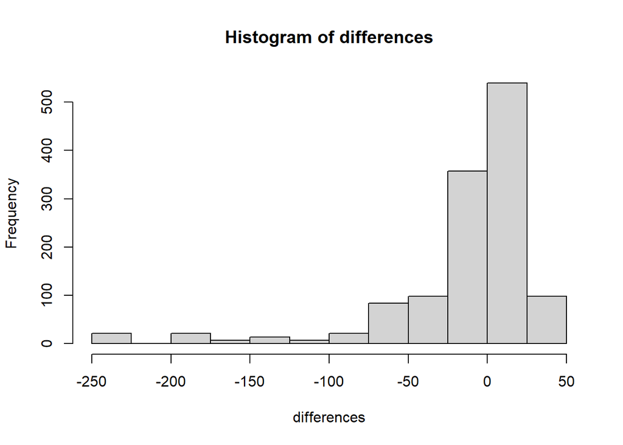

```r
hist(differences, breaks = seq(-250, 50, 25))
```

Now calculate some simple summary statistics of the differences.

```r
# Mean
mean(differences)
```

```
[1] -13.7887
```

```r
# Range
range(differences)
```

```
[1] -237.0205   48.0000
```

```r
# Median
median(differences)
```

```
[1] 0.3383713
```

**Question 1** What information do your simple analyses provide that can’t be seen on a map? Overall, what do the results say about the performance of the model for lilac leaf out?

## **Exercise 2: Apply custom functions to raster data**

Custom functions allow us to:

- Avoid repeating code
- Improve readability
- Increase reproducibility
- Apply the same workflow to many rasters
- Simplify complex analyses

## **(1) Evaluating temperature anomalies**

We’ll move on from the lilac modeling data set to climate change. Specifically, well ask this question: for each year between 2020 and 2024, which OR counties experienced the largest July temperature anomalies relative to the 30-year average?

### **Data preparation**

We will use three data sets:

1. Tmax for July for 2020, 2021, 2022, 2023 and 2024 (5 rasters)
2. Average Tmax for July between 1981-2010 (1 raster)
3. U.S. county simple features (sf) object

Take a peek at the raster data - there are 872,505 raster cell values

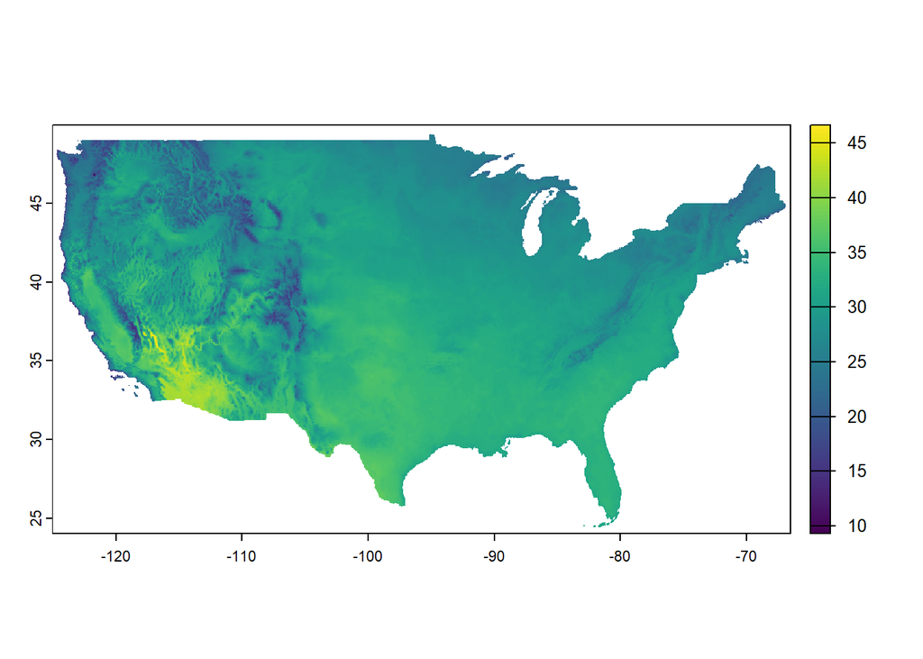

```r
Jul_30yrAv <- rast(Jul_30yrAv_fl)

plot(Jul_30yrAv)
```

Import the county boundary data (`counties.shp`) and filter out counties for OR.

```r
# US counties feature
counties <- st_read(here("data", "counties.shp"))
# Subset (filter) Oregon counties only
countiesOR <- counties %>%
  filter(stat_nm == "Oregon")
```

### **Apply the function across years**

Use `lapply` to apply the function across `1:length(July_fls)`.

```r
results <- lapply(1:length(Jul_fls), top_county_func)
results
```

```
[[1]]
   county anomaly_F
1 Klamath  1.477463
2    Lake  1.354094
3   Crook  1.347020
4 Wallowa -1.340586
5   Union -1.035025

[[2]]
   county anomaly_F
1   Crook  8.439179
2 Wallowa  8.072446
3   Baker  7.779748
4   Union  7.321412
5 Wheeler  7.239968

[[3]]
     county anomaly_F
1     Crook  5.665660
2     Wasco  5.256610
3 Deschutes  4.930424
4      Lake  4.747723
5   Sherman  4.720275

[[4]]
     county anomaly_F
1     Crook  5.463186
2      Polk  5.008857
3   Douglas  4.735753
4    Benton  4.664928
5 Deschutes  4.592564

[[5]]
     county anomaly_F
1   Klamath  7.256696
2     Crook  6.452571
3      Lake  6.435161
4 Deschutes  6.244056
5 Jefferson  6.117603
```

**Question 1.** Which OR county had the largest difference (anomaly) in temperature (F) from the 30-year average for July?

The output shows which 5 OR counties had the largest difference (anomaly) in temperature (F) from the 30 year average for July. The largest anomalies are for `2021`, a year with record-breaking heat for Oregon.

#### **Practice 1** Modify the raster function

**1.** Add median, standard deviation, and maximum anomaly values.

**2.** Return counties with the most negative anomalies.

**3.** Modify the function so it returns the top 10 counties instead of 5.

## **(2) Direction of change in annual Tmax**

How has annual maximum temperature (Tmax) changed across Oregon between 1990 and 2019?

Load annual data.

```r
USA_fls <- list.files(
  here("data", "prism_data", "annual"),
  pattern = ".bil$",
  full.names = TRUE
)
```

### **Function: regression model of Tmax**

The `slope_func` function below loads, crops, and subsets annual Tmax rasters and then runs a regression model for each raster grid cell. The results will provide insight into the direction of change in annual Tmax for each decade.

```r
slope_func <- function(years) {

  # Get rasters and crop to OR, and retain layers of corresponding years
  USA_r <- rast(USA_fls)

  # Crop the raster data
  OR_r <- crop(
    USA_r,
    ext(-124.7294, -116.2949, 41.7150, 46.4612)
  )

  # Subset raster layer for the year range
  OR_r <- OR_r[[years]]

  # Run a regression model for each cell of the raster stack
  rm <- regress(
    OR_r,
    1:nlyr(OR_r),
    na.rm = TRUE
  )
   return(rm)
}
```

Analyze the trend of annual Tmax for each decade.

```r
# Decades
year_sets <- list(
  1:10, # 1990-1999
  11:20, # 2000-2010
  21:30 # 2011-2020
)
```

Apply the function below.

```r
slopes <- lapply(year_sets, slope_func)
```

Take a look at the trend results. What does each list element correspond to?

```r
slopes
```

```
[[1]]
class       : SpatRaster
size        : 114, 202, 2  (nrow, ncol, nlyr)
resolution  : 0.04166667, 0.04166667  (x, y)
extent      : -124.7292, -116.3125, 41.72917, 46.47917  (xmin, xmax, ymin, ymax)
coord. ref. : lon/lat NAD83
source(s)   : memory
names       : (Intercept),          x
min values  :    2.094933, -0.2184364
max values  :   21.651601,  0.1695636

[[2]]
class       : SpatRaster
size        : 114, 202, 2  (nrow, ncol, nlyr)
resolution  : 0.04166667, 0.04166667  (x, y)
extent      : -124.7292, -116.3125, 41.72917, 46.47917  (xmin, xmax, ymin, ymax)
coord. ref. : lon/lat NAD83
source(s)   : memory
names       : (Intercept),          x
min values  :      2.3114, -0.2512727
max values  :     21.8192,  0.1406363

[[3]]
class       : SpatRaster
size        : 114, 202, 2  (nrow, ncol, nlyr)
resolution  : 0.04166667, 0.04166667  (x, y)
extent      : -124.7292, -116.3125, 41.72917, 46.47917  (xmin, xmax, ymin, ymax)
coord. ref. : lon/lat NAD83
source(s)   : memory
names       : (Intercept),          x
min values  :    1.437073, -0.1061164
max values  :   20.846581,  0.2737309
```

For increased clarity, we can rename the list elements. These can be used for titles for creating basic plots in `terra`.

```r
names(slopes) <- c( "OR_1990_1999",  "OR_2000_2010",  "OR_2011_2020")
```

Let’s look at the results. Annual Tmax exhibited different trends throughout OR if we look at each decade separately, but temperatures are generally increasing in many areas. The `x` layer in each raster corresponds to the slope - i.e., the trend in annual Tmax for the respective time periods. We can plot these results by referencing the second layer for each list element.

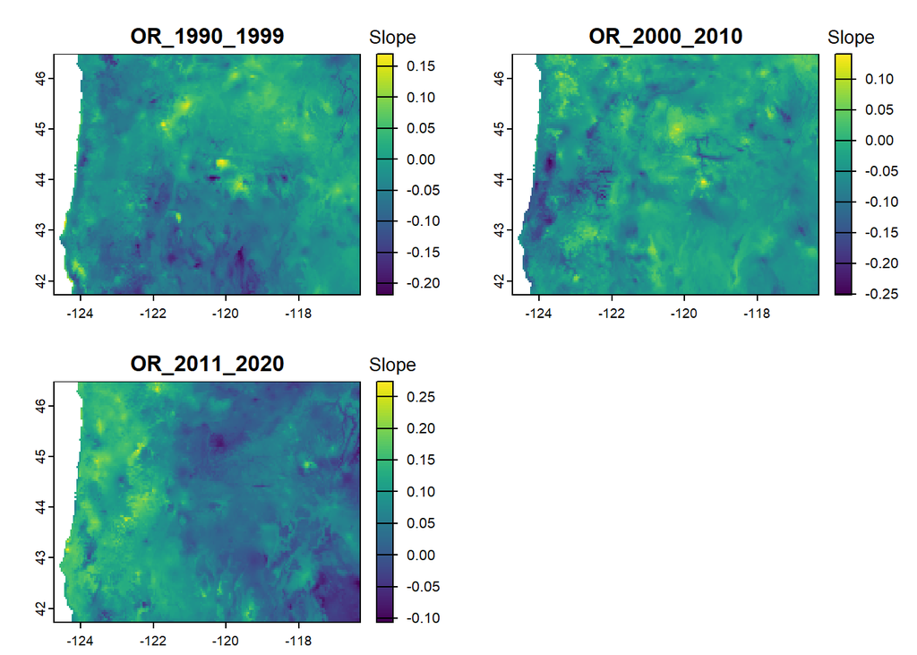

**Question 2.** Overall, which decade did Tmax increase at the fastest rate?

#### **Practice 2** Modify the trend function

**4.** Change the extent to a different state.

**5.** Change the time frame to a longer period, such as `20` or `30` years.

Visualize the Tmax trends by Oregon county for 2011-2020. Here we convert `countiesOR` to a `SpatVector` format, which is designed for vector data in the `terra` package. You can save the results as a polygon and easily plot the results. By default, the output column name is `x`.

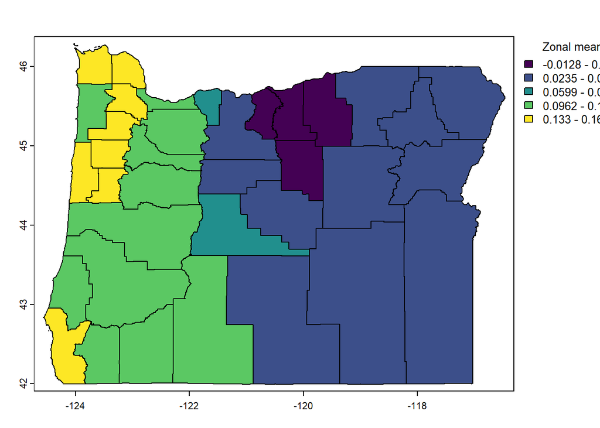

```r
# Convert the sf feature to a SpatVector
countiesOR_v <- vect(countiesOR)

# Calculate zonal stats
slope_zonal <- zonal(slopes[[3]][[2]], countiesOR_v,
                     fun = "mean", as.polygons = TRUE)

# Plot
plot(slope_zonal, y = "x",
     plg=list(title="Zonal mean"))
```

#### **Practice 3** Make a nicer plot

**6.** Practice your `ggplot2` mapping skills to make a nicer map! (Hint: the data is `countiesOR_z` and values are `mean`). A nice addition could be a title like “Mean Rate of Tmax Change in Oregon (2011-2020)”, and you can visualized county names using `geom_sf_text()`.

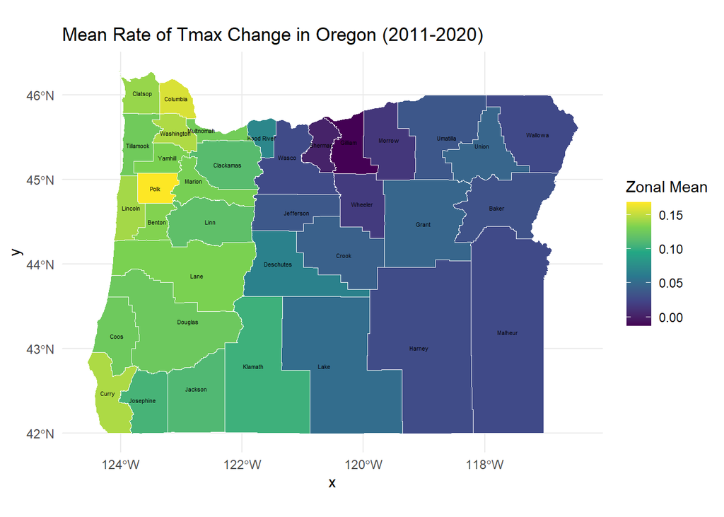

```r
# Bind the mean value column to the OR counties feature
countiesOR_z <- bind_cols(countiesOR, mean = slope_zonal$x)

# Make a ggplot
ggplot(data = countiesOR_z) +
  geom_sf(aes(fill = mean), color = "white", size = 0.2) +
  geom_sf_text(aes(label = name), size = 1.5) +
  scale_fill_viridis_c(name = "Zonal Mean") + # Clean, continuous color palette
  theme_minimal() +
  labs(
    title = "Mean Rate of Tmax Change in Oregon (2011-2020)"
  )
```

**Question 3.** Which county experienced the largest increase in Tmax between 2011-2020?

## **Wrap up**

We focused on using `terra` to extract and analyze raster and vector data. The package is large and extensive, with dozens (or hundreds!) of functions, and an ability to do parallel processing to speed up operations. Thus, it’s very powerful and an integral to working with rasters in R.

## **Potentially useful tutorials, free books, etc.**

**Compilation of various resources**  
- [R Spatial data science blogs](https://r-spatial.org/)

**Books**  
- [Geocomputation with R](https://r.geocompx.org/) by R. Lovelace et al. (2025)  
- [Geographic Data Science with R](https://bookdown.org/mcwimberly/gdswr-book/) by M.C. Wimberly (2023)

**Tutorials/vignettes**  
- [Spatial Data Science with R and “terra”](https://rspatial.org/) by R. Hijmans (2019-2025)  
- [Geospatial workskop](https://datacarpentry.org/lessons/#geospatial) by NEON  
- [Introduction to Spatial Raster Data Using the terra Package](https://rpubs.com/GeospatialEcologist/SpatialRaster) by J. Carrell (2023)  
- [Introduction to rasters with terra](https://emlab-ucsb.github.io/intro-terra/) by J. Flower  
- [Intro to GIS in R](https://rpubs.com/hannah0/GIS_with_terra) by H. Owens  
- [Raster analysis with terra](https://www.wvview.org/os_sa/15_Raster_Analysis_terra.html) by WVview

## **Acknowledgements**

Development of this workshop was supported by the USDA National Institute of Food and Agriculture (NIFA) Agriculture and Food Research Initiative program (#2022-68013-37138) and USDA NIFA Crop and Pest Management program (#2024-70006-43503).